========================================================  
Report MOOC Machine Learning  
June, 2014  
——————————————————–

## Step 0 - Loading package and data

```r
# Load Packages
library(caret)
#Load data
pmltraining<-read.csv("./Data/pml-training.csv", na.strings=c("NA","")) # transform empty space to NAs
dim(pmltraining)
```

```
## [1] 19622   160
```

The dataset contains 19622 observations of 160 variables.

## Step 1 - Creating training/testing files

Before all analyses, the dataset is splitted into a training and a testing file, so the exploration of the data are done only in the training file.  
The size of the training set is chosen to contain 25% of the data, in order to avoid large computing time during the model training.

```r
inTrain<-createDataPartition(y=pmltraining$classe, p=0.25, list=FALSE) # 25% of the data in training
trainingraw<-pmltraining[inTrain,]
testingraw<-pmltraining[-inTrain,]
dim(trainingraw)
```

```
## [1] 4907  160
```

```r
dim(testingraw)
```

```
## [1] 14715   160
```

## Step 2 - Exploring data

The goal of this step is to explore the different variable, in order to identify which column might be kept for the model training.  
Some predictors are non-sensor data (based on the column name) and/or have a too-good-to-be-true correlation with the outcome. In the following plot for instance, X is too correlated with the outcome, timestamp and new_window are not sensor data.

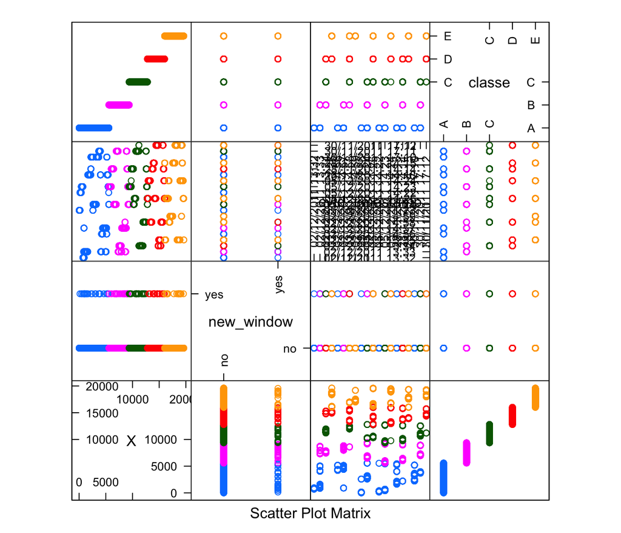

```r
featurePlot(x=trainingraw[,c("X","new_window","cvtd_timestamp", "classe")],
            y=trainingraw$classe, plot="pairs")
```

Contrarily, other columns do contain sensor measurements, and could be used as predictors to train a model. For instance, the variables roll_belt, pitch_forearm and yaw_belt.

### Density plot for roll_belt

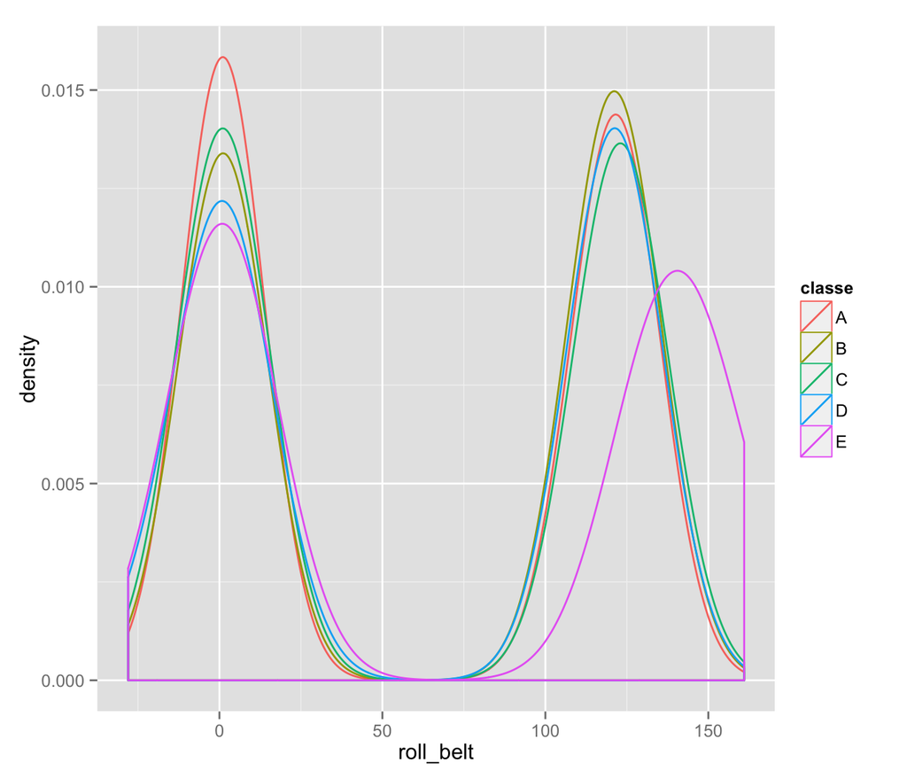

```r
#density plot
qplot(roll_belt, colour=classe, data=trainingraw, geom="density")
```

### boxplot for pitch_forearm

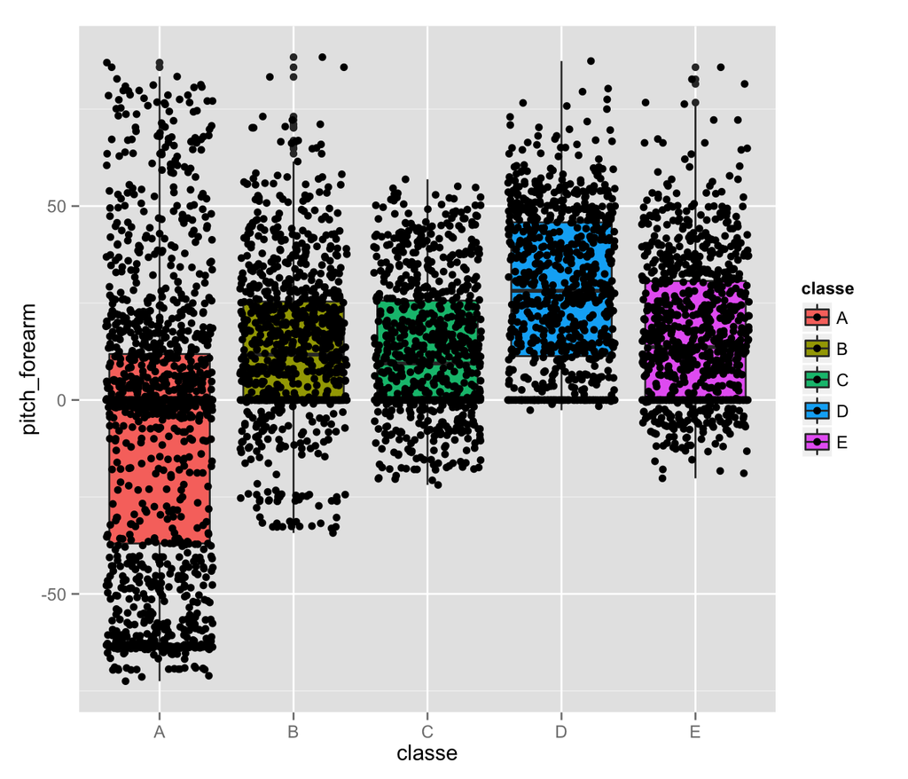

```r
#boxplot
p1<-qplot(classe, pitch_forearm, fill=classe, data=trainingraw, geom=c("boxplot", "jitter"))
p1
```

### boxplot for yaw_belt

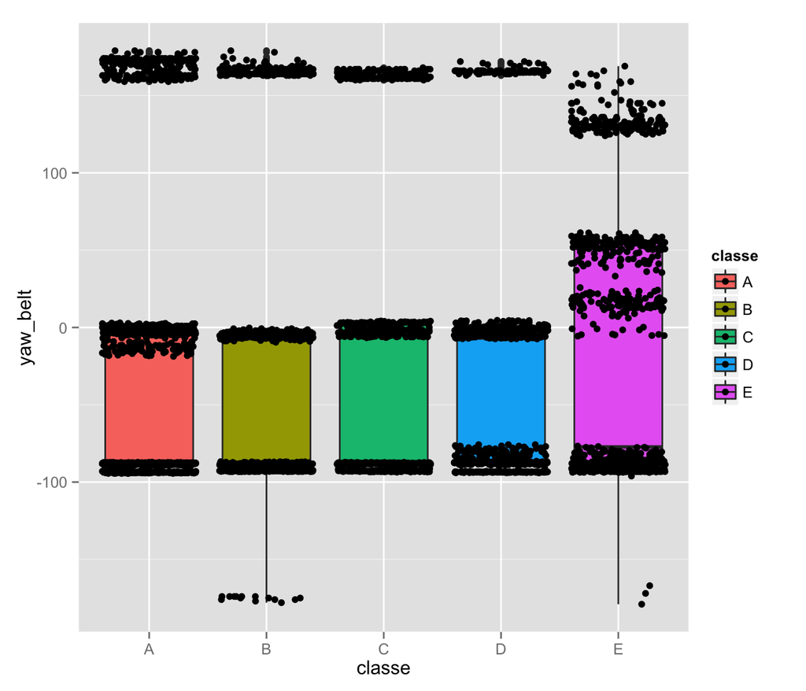

```r
p2<-qplot(classe, yaw_belt, fill=classe, data=trainingraw, geom=c("boxplot", "jitter"))
p2
```

## Step 3 - Cleaning data

The raw dataset contains 160 columns, and after cleaning of columns containing NAs, empty space, or not related to sensor data 53 columns (including the outcome class) remain.

```r
# Remove columns containing NAs (and empty spaces)
trainingrawnoNA<-trainingraw[sapply(trainingraw, function(x) !any(is.na(x)))]
dim(trainingrawnoNA)
```

```
## [1] 4907   60
```

```r
# Remove columns containing non-sensors related data
colrm<-c("X","user_name", "num_window", "new_window", "raw_timestamp_part_1",
         "raw_timestamp_part_2", "cvtd_timestamp")
training<-trainingrawnoNA[,!names(trainingrawnoNA) %in% colrm]
dim(training)
```

```
## [1] 4907   53
```

## Step 3 - Training

### Modeling

```r
set.seed(42)

modelFit<-train(training$classe~., method="rf", trControl=trainControl(method="cv", number=10),
                   data=training)
```

### Explications of the method and the parameters

- Different training method were tested. Some are not adapted to the 5-classes outcomes we are trying to predict (like method=“glm”), others give very bad accuracies (for instance, method=“rpart”). The chosen train method, after some exploration, is Random Forest. Using the carret package, the argument is method=“rf”.
- Preprocessing. The data could be preprocessed with, for instance, PCA (Principal Component Analysis). However, preprocessing the data didn’t increase the accuracy, and lead to an interpretation of the results that is more difficult, concerning in particular the importance of the different parameters.
- trControl. The default trControl is bootstrap. As we’re interested here in the cross-validation, the trControl was paramatrized to use this approach, with a partition in 10 folds. Furthermore, cross-validation is less time consumming than bootstrap.

```r
modelFit$finalModel
```

```
##
## Call:
##  randomForest(x = x, y = y, mtry = param$mtry)
##                Type of random forest: classification
##                      Number of trees: 500
## No. of variables tried at each split: 27
##
##         OOB estimate of  error rate: 2.16%
## Confusion matrix:
##      A   B   C   D   E class.error
## A 1389   4   1   1   0    0.004301
## B   21 910  17   1   1    0.042105
## C    0  16 833   7   0    0.026869
## D    1   3  17 781   2    0.028607
## E    0   2   4   8 888    0.015521
```

## Step 4 - Applying the model to the testing dataset

```r
# Remove columns containing NAs (and empty spaces)
testingrawnoNA<-testingraw[sapply(testingraw, function(x) !any(is.na(x)))]
dim(testingrawnoNA)
```

```
## [1] 14715    60
```

```r
# Remove columns containing non-sensors related data
colrm<-c("X","user_name", "num_window", "new_window", "raw_timestamp_part_1",
         "raw_timestamp_part_2", "cvtd_timestamp")
testing<-testingrawnoNA[,!names(testingrawnoNA) %in% colrm]
dim(testing)
```

```
## [1] 14715    53
```

## Applying the model

```r
predictions<-predict(modelFit, newdata=testing)
summary(predictions)
```

```
##    A    B    C    D    E
## 4248 2801 2590 2401 2675
```

## Confusion matrix

The confusion matrix permits to see that all classes have a good accuracy, the model is predicting correctly all classes (as also indicated by the Kappa concordance measure).

```r
#out of sample error
cm<-confusionMatrix(predictions, testing$classe)
cm
```

```
## Confusion Matrix and Statistics
##
##           Reference
## Prediction    A    B    C    D    E
##          A 4153   91    0    3    1
##          B   10 2711   58   10   12
##          C    9   40 2484   46   11
##          D   10    4   24 2343   20
##          E    3    1    0   10 2661
##
## Overall Statistics
##
##                Accuracy : 0.975
##                  95% CI : (0.973, 0.978)
##     No Information Rate : 0.284
##     P-Value [Acc > NIR] : <2e-16
##
##                   Kappa : 0.969
##  Mcnemar's Test P-Value : <2e-16
##
## Statistics by Class:
##
##                      Class: A Class: B Class: C Class: D Class: E
## Sensitivity             0.992    0.952    0.968    0.971    0.984
## Specificity             0.991    0.992    0.991    0.995    0.999
## Pos Pred Value          0.978    0.968    0.959    0.976    0.995
## Neg Pred Value          0.997    0.989    0.993    0.994    0.996
## Prevalence              0.284    0.193    0.174    0.164    0.184
## Detection Rate          0.282    0.184    0.169    0.159    0.181
## Detection Prevalence    0.289    0.190    0.176    0.163    0.182
## Balanced Accuracy       0.992    0.972    0.980    0.983    0.991
```

The overall accuracy of the model is:

```r
cm$overall[1]
```

```
## Accuracy
##   0.9753
```

The varImp call gives the importance of the different predictors for the model. Noticeabily, these indications would have been PC1, PC2… if we would have preprocessed the data with PCA. Here, we can see that roll_belt is the most important predictor for the model.

```r
varImp(modelFit, scale=TRUE)
```

```
## rf variable importance
##
##   only 20 most important variables shown (out of 52)
##
##                      Overall
## roll_belt             100.00
## pitch_forearm          59.58
## yaw_belt               53.45
## roll_forearm           45.98
## magnet_dumbbell_z      44.90
## magnet_dumbbell_y      43.40
## pitch_belt             40.46
## accel_dumbbell_y       24.85
## magnet_dumbbell_x      20.12
## accel_forearm_x        19.73
## roll_dumbbell          17.58
## magnet_forearm_z       16.31
## magnet_belt_z          15.54
## accel_dumbbell_z       14.94
## magnet_belt_y          14.65
## total_accel_dumbbell   13.18
## magnet_belt_x          11.36
## accel_belt_z           10.75
## yaw_dumbbell            8.87
## gyros_dumbbell_y        8.79
```

### Conclusion

The model has a very low error rate, in-sample and out-of-sample. This indicates that among the predictors, there are very strong predictors, such as roll_belt.